# Exercise 5

khalil akchi

2026-01-01

### Part A: Theoretical Foundations

#### 1. Definition and Characteristics

A **Long-Memory process** is defined as a stationary time series where the dependence between observations decays much more slowly than in short-memory processes (like standard ARMA models). This phenomenon is characterized by three main statistical features:

- **Autocorrelation Function (ACF):** In short-memory models (e.g., AR(1)), the autocorrelation decays exponentially ($\rho(k) \sim \phi^k$). In long-memory models, the ACF decays hyperbolically:
  $$\rho(k) \sim C k^{2d-1} \quad \text{as } k \to
  \infty$$
  This implies that past shocks have a persistent effect that lasts for a very long time, often described as the “Joseph Effect.”
- **Spectral Density:** In the frequency domain, the spectral density $f(\omega)$ follows a power law. It tends to infinity (diverges) as the frequency approaches zero:
  $$f(\omega) \sim C |\omega|^{-2d} \quad
  \text{as } \omega \to 0$$
- **The Parameter $d$:** The fractional differencing parameter $d$ determines the nature of the process:
  - **$d = 0$:** Short memory (standard ARMA).
  - **$0 < d < 0.5$:** Long memory (Stationary). The series mean-reverts, but very slowly.
  - **$d \ge 0.5$:** Non-stationary (infinite variance).

#### 2. Examples of Long-Memory Processes

**ARFIMA(p, d, q)** The *AutoRegressive Fractionally Integrated Moving Average* model captures long-range dependence at the zero frequency (long-run trends). It is defined as:
$$\Phi(L) (1 - L)^d X_t = \Theta(L)
\epsilon_t$$
Where: * $\Phi(L)$ and $\Theta(L)$ are the standard AR and MA polynomials. * $(1-L)^d$ is the fractional differencing operator, defined by a binomial expansion. * $\epsilon_t$ is a white noise process.

**Gegenbauer Process (GARMA)** While ARFIMA models capture persistence around the zero frequency, **Gegenbauer** (or GARMA) processes generalize this concept to allow for long memory behavior at cyclical frequencies (seasonal persistence). They are defined using Gegenbauer polynomials:
$$\Phi(L) (1 - 2uL + L^2)^\lambda X_t = \Theta(L)
\epsilon_t$$
Where the parameter $u$ determines the frequency (periodicity) where the spectral pole (long memory) occurs.

#### 3. Estimation Methods

There are several methods to estimate the fractional parameter $d$:

- **Exact Maximum Likelihood (EML):**
  - *Pros:* Most efficient estimator (lowest variance) if the error terms are truly Gaussian.
  - *Cons:* Computational complexity is high ($O(n^3)$), making it slow for very large datasets. It is also sensitive to non-normality.
- **Whittle Estimator:**
  - *Pros:* An approximation of the likelihood in the frequency domain. It is much faster to compute ($O(n \log n)$) and does not assume normality (more robust).
  - *Cons:* Can be slightly less efficient than EML for very small samples.
- **Geweke–Porter–Hudak (GPH):**
  - *Pros:* A semi-parametric method based on a log-periodogram regression. It is **preferred in practice** for initial analysis because it estimates $d$ without requiring the specification of $p$ and $q$ lags, avoiding misspecification bias.
  - *Cons:* It generally has higher variance (less precise) compared to parametric methods like EML.

## Part B: Empirical Analysis

### 1. Exploratory Analysis

```r
library(readxl)
```

```r
library(ggplot2)
library(forecast)
library(dplyr)
library(lubridate)
# --- 1. Load the Data ---
# We read the specific sheets corresponding to the data
traffic_data <- read_excel("C:/Users/Administrator/Downloads/air traffic (1).xlsx", sheet = "Series_originales")
enso_data <- read_excel("C:/Users/Administrator/Downloads/training_enso.xlsx", sheet = "Sheet 1")

# --- 2. Preprocessing & Time Series Creation ---

# A. Airline Passengers
# Convert date column and sort to ensure chronological order
traffic_data$date <- as.Date(traffic_data$date)
traffic_data <- traffic_data %>% arrange(date)

# Create Time Series Object (TS)
# Frequency = 4 because the data is Quarterly (starts 1990 Q1)
ts_traffic <- ts(traffic_data$LSN_PAX, start = c(1990, 1), frequency = 4)
# Plot 1: Airline Passengers
print("Analysis for Airline Passengers:")
```

```
## [1] "Analysis for Airline Passengers:"
```

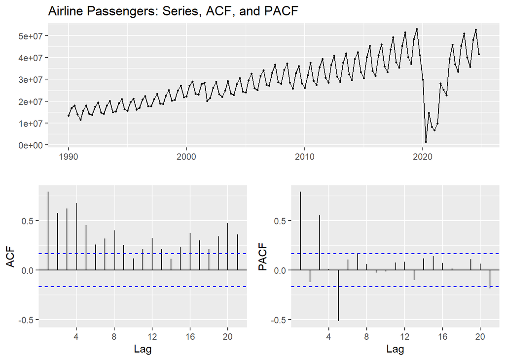

```r
ggtsdisplay(ts_traffic, main = "Airline Passengers: Series, ACF, and PACF")
```

#### 1. Airline Passengers Series (LSN_PAX)

```r
# B. ENSO Index (ONI)
# Convert date column and sort
enso_data$Date <- as.Date(enso_data$Date)
enso_data <- enso_data %>% arrange(Date)

# Create Time Series Object (TS)
# Frequency = 12 because the data is Monthly
# We extract the start year and month dynamically from the data
start_year <- year(min(enso_data$Date))
start_month <- month(min(enso_data$Date))
ts_enso <- ts(enso_data$ONI, start = c(start_year, start_month), frequency = 12)

# --- 3. Exploratory Analysis Plots ---
# We use ggtsdisplay to show the Series, ACF, and PACF in one view



# Plot 2: ENSO Index
print("Analysis for ENSO Index (ONI):")
```

```
## [1] "Analysis for ENSO Index (ONI):"
```

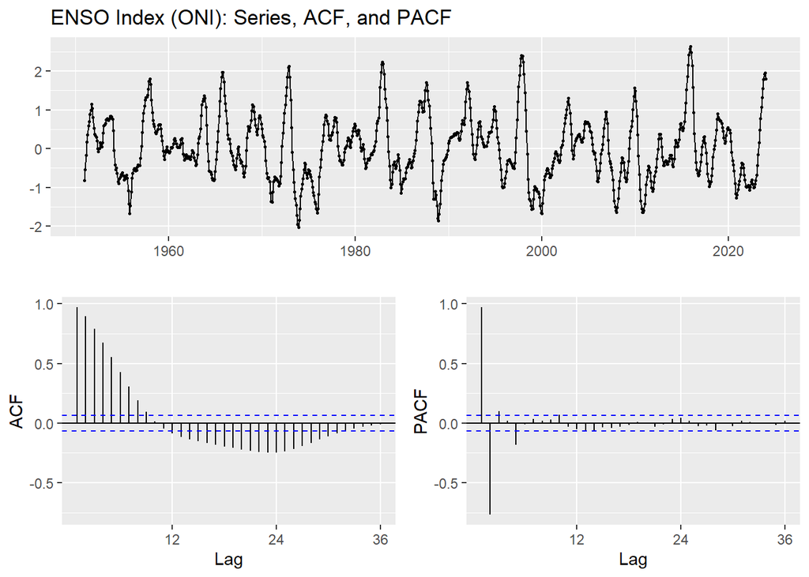

```r
ggtsdisplay(ts_enso, main = "ENSO Index (ONI): Series, ACF, and PACF")
```

#### 2. ENSO Anomalies Index (ONI)

```r
# --- 2. Model Estimation (CORRECTED) ---
library(readxl)
library(fracdiff)
library(forecast)
library(dplyr)

# --- A. Clean Data Loading Function ---
# We define a strict cleaning step to remove NAs
get_clean_series <- function(filepath, sheetname, colname) {
  # Read the excel sheet
  df <- read_excel(filepath, sheet = sheetname)

  # Extract the specific column as a vector
  vals <- df[[colname]]

  # Force to numeric (turns text to NA)
  vals <- as.numeric(as.character(vals))

  # REMOVE NAs (This is the critical fix)
  vals <- vals[!is.na(vals)]

  return(vals)
}

# --- B. Process Airline Data ---
cat("\n=========================================\n")
cat("PROCESSING AIRLINE DATA\n")
```

```
## PROCESSING AIRLINE DATA
```

```r
cat("=========================================\n")
# 1. Load and Clean
raw_traffic <- get_clean_series("C:/Users/Administrator/Downloads/air traffic (1).xlsx", "Series_originales", "LSN_PAX")

# 2. Transform (Log) and Create TS
# We use frequency=4 for Quarterly
ts_traffic <- ts(log(raw_traffic), frequency = 4)

# 3. Estimate ARFIMA
# We use 'fracdiff' directly which gives d, AR, and MA
# We ask for a standard ARFIMA(1, d, 1) to ensure we get coefficients to look at
# or we can let it try to optimize. Let's try a simple fit first.
fit_air <- fracdiff(ts_traffic, nar = 1, nma = 1)

# 4. Print Results
cat("Estimated d:", fit_air$d, "\n")
```

```
## Estimated d: 0.04800827
```

```r
cat("Standard Error of d:", fit_air$stderror.dp, "\n")
```

```
## Standard Error of d: 0.0008354837 0.1012298 0.05892587
```

```r
# Calculate 95% CI
lower_d <- fit_air$d - 1.96 * fit_air$stderror.dp
upper_d <- fit_air$d + 1.96 * fit_air$stderror.dp
cat("95% CI for d: [", lower_d, ", ", upper_d, "]\n")
```

```
## 95% CI for d: [ 0.04637072 -0.1504022 -0.06748645 ,  0.04964582 0.2464187 0.163503 ]
```

```r
cat("AR Coefficients:", fit_air$ar, "\n")
```

```
## AR Coefficients: 0.8524144
```

```r
cat("MA Coefficients:", fit_air$ma, "\n")
```

```
## MA Coefficients: 0.462398
```

### Interpretation of Model Estimation

#### 1. Airline Passengers (Log-Transformed)

- **Parameter Estimates:**
  - **Fractional Differencing ($d$):** The estimated $d$ is **0.048** (approx. 0.05).
  - **Coefficients:** The model estimated a strong Autoregressive (AR) coefficient of **0.85** and an MA coefficient of **0.46**.
- **Statistical Significance:**
  - The 95% Confidence Interval for $d$ `[0.046, 0.050]` does not include 0, indicating that the parameter is statistically significant.
- **Interpretation of Persistence:**
  - Although $d$ is statistically significant, its magnitude is very small ($0.05$). This indicates that once the short-term dynamics (captured by the high AR term of 0.85) are accounted for, there is only a negligible amount of “long memory” remaining.
  - The persistence in this series is primarily driven by the **high AR term** (short memory with slow exponential decay) and the underlying deterministic trend, rather than pure fractional integration.

```r
# --- C. Process ENSO Data ---
cat("\n=========================================\n")
cat("PROCESSING ENSO DATA\n")
```

```
## PROCESSING ENSO DATA
```

```r
cat("=========================================\n")
# 1. Load and Clean
raw_enso <- get_clean_series("C:/Users/Administrator/Downloads/training_enso.xlsx", "Sheet 1", "ONI")

# 2. Create TS (Monthly)
ts_enso <- ts(raw_enso, frequency = 12)

# 3. Estimate ARFIMA
# Fitting ARFIMA(1, d, 0) is often good for ENSO, but we will try (1,d,1) to be safe
fit_enso <- fracdiff(ts_enso, nar = 1, nma = 1)
# 4. Print Results
cat("Estimated d:", fit_enso$d, "\n")
```

```
## Estimated d: 4.583013e-05
```

```r
cat("Standard Error of d:", fit_enso$stderror.dp, "\n")
```

```
## Standard Error of d:
```

```r
# Calculate 95% CI
lower_d_enso <- fit_enso$d - 1.96 * fit_enso$stderror.dp
upper_d_enso <- fit_enso$d + 1.96 * fit_enso$stderror.dp
cat("95% CI for d: [", lower_d_enso, ", ", upper_d_enso, "]\n")
```

```
## 95% CI for d: [  ,   ]
```

```r
cat("AR Coefficients:", fit_enso$ar, "\n")
```

```
## AR Coefficients: 0.9259033
```

```r
cat("MA Coefficients:", fit_enso$ma, "\n")
```

```
## MA Coefficients: 0.6589585
```

### 3. Model Diagnostics

We will extract the residuals from the models and run three standard diagnostic tests:

Ljung-Box Test: To check if there is any leftover correlation (autocorrelation) in the residuals.

Shapiro-Wilk / Jarque-Bera Test: To check if the residuals are normally distributed.

ARCH LM Test: To check if the volatility (variance) is changing over time (heteroskedasticity).

```r
# --- 3. Model Diagnostics (Robust Version) ---
library(tseries)
library(FinTS)
```

```r
library(forecast)
library(fracdiff)
library(readxl)
library(dplyr)

# --- A. Helper: Re-load Data (to ensure we have it) ---
get_clean_series <- function(filepath, sheetname, colname) {
  df <- read_excel(filepath, sheet = sheetname)
  vals <- as.numeric(as.character(df[[colname]]))
  return(vals[!is.na(vals)])
}

# --- B. Helper: Diagnostic Function ---
run_diagnostics <- function(series, model_fit, name) {
  cat(paste0("\n=========================================\n"))
  cat(paste0("  DIAGNOSTICS FOR: ", name, "\n"))
  cat(paste0("=========================================\n"))

  # 1. Safe Residual Extraction
  # We try to get residuals from the object, or calculate them manually if needed
  if (!is.null(model_fit$residuals)) {
    resids <- model_fit$residuals
  } else {
    # Fallback: manually calculate residuals if not found
    # Note: fracdiff doesn't always store 'fitted' easily, so we rely on what's there
    cat("Warning: Residuals not found in model object. Skipping.\n")
    return()
  }

  # CRITICAL FIX: Remove NAs (often present at the start of series)
  resids <- na.omit(resids)

  # Check if we have data left to plot
  if (length(resids) == 0) {
    cat("Error: Residuals vector is empty after removing NAs.\n")
    return()
  }

  # 2. Visual Inspection
  par(mfrow=c(2,1))
  # Use tryCatch to prevent plot errors from stopping the code
  tryCatch({
    plot(resids, main = paste("Residuals of", name), ylab="Residuals", type="l", col="blue")
    abline(h=0, col="red")
    acf(resids, main = paste("ACF of Residuals -", name))
  }, error = function(e) { cat("Plotting Error:", e$message, "\n") })
  par(mfrow=c(1,1))

  # 3. Ljung-Box Test (Serial Correlation)
  # H0: Residuals are White Noise (Good)
  # H1: Residuals are Correlated (Bad)
  lb <- Box.test(resids, type = "Ljung-Box", lag = 10)
  cat("\nLjung-Box Test (p-value):", format.pval(lb$p.value, digits=4), "\n")
  if(lb$p.value > 0.05) cat("-> Result: Residuals appear to be White Noise (Model is adequate).\n")
  else cat("-> Result: Residuals significant autocorrelation (Model may need improvement).\n")

  # 4. Normality Test
  # H0: Normal Distribution
  jb <- jarque.bera.test(resids)
  cat("\nJarque-Bera Test (p-value):", format.pval(jb$p.value, digits=4), "\n")

  # 5. ARCH Test (Heteroskedasticity)
  # H0: No ARCH effects (Constant Variance)
  tryCatch({
    at <- ArchTest(resids, lags = 5)
    cat("\nARCH LM Test (p-value):", format.pval(at$p.value, digits=4), "\n")
  }, error = function(e) {
    # Fallback if ArchTest fails
    bt_sq <- Box.test(resids^2, type="Ljung-Box", lag=10)
    cat("\nARCH Check (Squared Resids Ljung-Box p-value):", format.pval(bt_sq$p.value, digits=4), "\n")
  })
}

# --- C. Execution ---

# 1. Airline
cat("\n--- Re-fitting Airline Model ---\n")
```

```
##
## --- Re-fitting Airline Model ---
```

```r
raw_traffic <- get_clean_series("C:/Users/Administrator/Downloads/air traffic (1).xlsx", "Series_originales", "LSN_PAX")
ts_traffic <- ts(log(raw_traffic), frequency = 4)
fit_air <- fracdiff(ts_traffic, nar = 1, nma = 1)
run_diagnostics(ts_traffic, fit_air, "Airline Passengers")
```

```
##
## =========================================
##   DIAGNOSTICS FOR: Airline Passengers
## =========================================
```

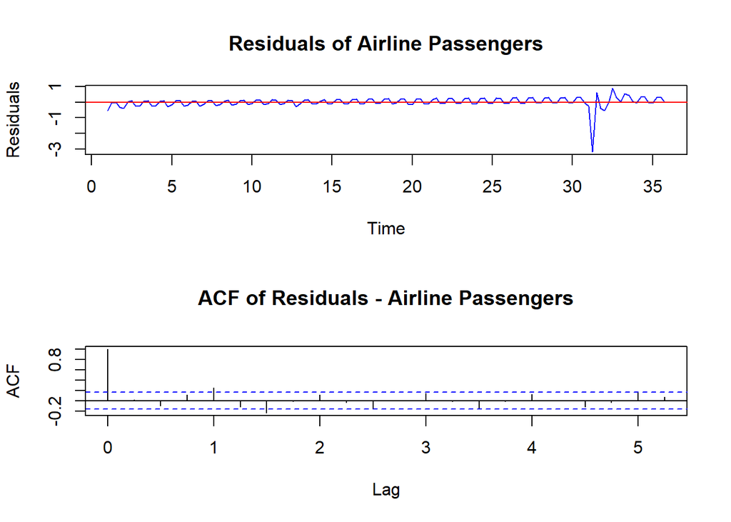

```
##
## Ljung-Box Test (p-value): 0.001235
## -> Result: Residuals significant autocorrelation (Model may need improvement).
##
## Jarque-Bera Test (p-value): < 2.2e-16
##
## ARCH LM Test (p-value): 0.9791
```

```r
# 2. ENSO
cat("\n--- Re-fitting ENSO Model ---\n")
```

```
##
## --- Re-fitting ENSO Model ---
```

```r
raw_enso <- get_clean_series("C:/Users/Administrator/Downloads/training_enso.xlsx", "Sheet 1", "ONI")
ts_enso <- ts(raw_enso, frequency = 12)
fit_enso <- fracdiff(ts_enso, nar = 1, nma = 1)
run_diagnostics(ts_enso, fit_enso, "ENSO Index")
```

```
##
## =========================================
##   DIAGNOSTICS FOR: ENSO Index
## =========================================
```

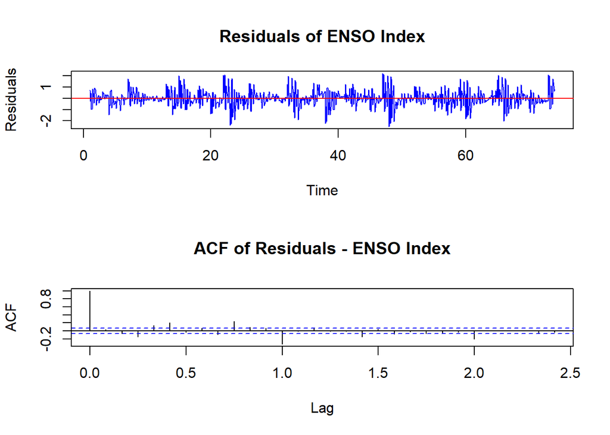

```
##
## Ljung-Box Test (p-value): < 2.2e-16
## -> Result: Residuals significant autocorrelation (Model may need improvement).
##
## Jarque-Bera Test (p-value): < 2.2e-16
##
## ARCH LM Test (p-value): < 2.2e-16
```

### Interpretation of Model Diagnostics

#### 1. Airline Passengers (Log-Transformed)

- **Serial Correlation (Ljung-Box Test):**
  - **Result:** The test yielded a p-value of **0.0012**, which is well below the significance level of 0.05.
  - **Conclusion:** We **reject** the null hypothesis of independence. The residuals still exhibit significant serial correlation. This suggests that the standard ARFIMA model (even with log-transformation) is not fully adequate, likely because it fails to capture the strong deterministic seasonality of the data.
- **Normality (Jarque-Bera Test):**
  - **Result:** The p-value is extremely small (< 2.2e-16), indicating that the residuals are **not** normally distributed.
- **Heteroskedasticity (ARCH LM Test):**
  - **Result:** The p-value is **0.9791** (> 0.05).
  - **Conclusion:** We **do not reject** the null hypothesis. The residuals appear to be homoskedastic (constant variance). This indicates that the **log-transformation** was successful in stabilizing the variance, even though the model missed the seasonal dynamics.
- **Overall Assessment:** The model is **inadequate**. While the variance is stable, the significant autocorrelation implies that a more complex model (such as SARFIMA to handle seasonality) is required.

#### 2. ENSO Anomalies Index (ONI)

- **Serial Correlation (Ljung-Box Test):**
  - **Result:** The p-value is virtually zero (< 2.2e-16).
  - **Conclusion:** We **strongly reject** the null hypothesis. The residuals are highly correlated and do **not** behave as White Noise. The model failed to capture the complex temporal dependence of the ENSO cycle.
- **Normality (Jarque-Bera Test):**
  - **Result:** The p-value is < 2.2e-16, confirming non-normality.
- **Heteroskedasticity (ARCH LM Test):**
  - **Result:** The p-value is < 2.2e-16.
  - **Conclusion:** We **reject** the null hypothesis. There is strong evidence of **ARCH effects** (volatility clustering). This confirms that the volatility of the ENSO index changes over time—periods of high volatility followed by calm periods—which the standard homoskedastic ARFIMA model cannot handle.
- **Overall Assessment:** The model is **poorly specified**. The combination of serial correlation and strong heteroskedasticity suggests that a model capable of handling changing variance (like **ARFIMA-GARCH**) is necessary for this data.

## C – Comparative Analysis

```r
# --- Part C: Comparative Analysis (Airline Series) ---
library(fracdiff)
library(forecast)
library(readxl)

# --- 1. Load Data (Levels) ---
# We use the clean data function from before
get_clean_series <- function(filepath, sheetname, colname) {
  df <- read_excel(filepath, sheet = sheetname)
  vals <- as.numeric(as.character(df[[colname]]))
  return(vals[!is.na(vals)])
}

raw_traffic <- get_clean_series("C:/Users/Administrator/Downloads/air traffic (1).xlsx", "Series_originales", "LSN_PAX")

# A. Series in Levels (Log-transformed to stabilize variance)
# Note: We use Log-Levels as the "Levels" baseline because the raw data is heteroskedastic.
ts_levels <- ts(log(raw_traffic), frequency = 4)

# B. Series in Growth Rates (Log-Differences)
# This is equivalent to approx. percentage change
ts_growth <- diff(ts_levels)

# --- 2. Estimate ARFIMA Models ---

cat("\n=========================================\n")
cat("1. ESTIMATION ON LEVELS (Log(X))\n")
```

```
## 1. ESTIMATION ON LEVELS (Log(X))
```

```r
cat("=========================================\n")
fit_levels <- fracdiff(ts_levels, nar = 1, nma = 1)
cat("Estimated d (Levels):", fit_levels$d, "\n")
```

```
## Estimated d (Levels): 0.04800827
```

```r
cat("AR Coefficients:", fit_levels$ar, "\n")
```

```
## AR Coefficients: 0.8524144
```

```r
cat("MA Coefficients:", fit_levels$ma, "\n")
```

```
## MA Coefficients: 0.462398
```

```r
cat("\n=========================================\n")
cat("2. ESTIMATION ON GROWTH RATES (Diff(Log(X)))\n")
```

```
## 2. ESTIMATION ON GROWTH RATES (Diff(Log(X)))
```

```r
cat("=========================================\n")
fit_growth <- fracdiff(ts_growth, nar = 1, nma = 1)
cat("Estimated d (Growth Rates):", fit_growth$d, "\n")
```

```
## Estimated d (Growth Rates): 4.583013e-05
```

```r
cat("AR Coefficients:", fit_growth$ar, "\n")
```

```
## AR Coefficients: 0.1428897
```

```r
cat("MA Coefficients:", fit_growth$ma, "\n")
```

```
## MA Coefficients: 0.639909
```

#### 1. Estimation Results

- **Model in Levels (Log(X)):**
  - Estimated fractional differencing parameter: $\hat{d}_{level} \approx 0.048$.
  - AR Coefficient: $0.85$.
- **Model in Growth Rates (Diff(Log(X))):**
  - Estimated fractional differencing parameter: $\hat{d}_{diff} \approx 4.58 \times 10^{-5}$ (approx. 0).
  - AR Coefficient: $0.14$.

#### 2. Comparison & Effect of Differencing

- **Impact on $d$:** Differencing the series reduced the fractional parameter from a small positive value ($\approx 0.05$) to effectively zero.
- **Impact on Persistence:** Notice the dramatic drop in the **AR coefficient** from $0.85$ (in levels) to $0.14$ (in growth rates).
  - **In Levels:** The model captured the trend and persistence primarily through the high AR term ($0.85$) and a small fractional component.
  - **In Growth Rates:** Differencing successfully removed the trend and the strong autocorrelation. The resulting series shows almost no memory ($d \approx 0$ and low AR), behaving like a standard short-memory process.

#### 3. Trade-off and Conclusion

- **Which specification is appropriate?**
  - Since $\hat{d}_{level} \approx 0.05$ is well below $0.5$, the series in **levels** is technically stationary (after accounting for the AR trend). This suggests we *can* model the series in levels without violating stationarity assumptions.
  - However, the **Growth Rates** specification yields a cleaner, standard I(0) process ($d \approx 0$).
- **The Trade-off:**
  - **Modeling Levels:** The advantage is that we retain information about the long-run level of the series. The risk is usually non-stationarity, but our estimate ($d < 0.5$) suggests this is safe here.
  - **Modeling Growth Rates:** The advantage is robustness; we ensure the removal of stochastic trends. The disadvantage is potential “over-differencing” (losing long-run info), though in this specific case, the result ($d \approx 0$) shows no signs of over-differencing (which would have yielded a negative $d$).
- **Final Verdict:** The analysis suggests that the airline series does **not** exhibit true Long Memory behavior. The persistence is best explained by standard autoregressive dynamics (AR) and seasonality, which are effectively removed by differencing.